# Notebook 02 - Dataset do histórico das vendas

### Definições iniciais

- Habilitação de recarga de módulo editado.

```python
%load_ext autoreload
%autoreload 2
```

- Pacotes de uso geral.

```python
import sys
import dtale    # instalado com: conda install dtale -c conda-forge
import numpy as np
import pandas as pd
from itertools import product
from tqdm.notebook import tqdm
from pprint import pformat # , pprint, PrettyPrinter
```

- Funções do pacote `bricklink_api`.
- Pacote `bricklinp_api`: https://github.com/BrickBytes/bricklink_api .
- Referência da API do Bricklink: https://www.bricklink.com/v3/api.page .

```python
from bricklink_api.auth import DefaultOAuth
from bricklink_api.catalog_item import get_price_guide, GuideType, NewOrUsed, Type
```

- Módulos em diretórios fora de `sys.path` .

```python
# diretório com módulos utilitários
sys.path.append('d:/py_utils')
```

```python
from pd_utils import (
    d_pd, exemplo_linha, resumo_tipos, resumo_categ, resumo_serie,
    DisplayPandas, ExemploLinha, ResumoTipos, ResumoCateg, ResumoSerie
)
```

- Módulos no diretório do notebook.

```python
from tcc import (
    ofuscar_params, frame2pickle, pickle2frame, object2pickle, pickle2object, coletar_dict)
```

- Utilidades de exibição e resumo de objetos `pandas`.

```python
# primeiro item, 4 items intermediárias, item final e dimensões de objeto pandas
h1s4t1 = DisplayPandas(head=1, sample=4, tail=1)
```

- Outras definições.

```python
d = display
pdod = pd.options.display
pdoc = pd.option_context
```

### Módulo `tcc`: variáveis comuns a mais de um notebook

```python
# módulo `tcc.py` na pasta do notebok com variáveis comuns aos notebooks
import tcc
```

```python
# caminhos
d(
      tcc.p_dir_tcc    # diretório inicial TCC
    , tcc.p_dir_bricklink    # diretório dados Bricklink
    , tcc.p_arq_autent    # parâmetros autenticação API Bricklink
    , tcc.pckl_df_guia_precos    # arquivo pickle dataframe
)
```

```
WindowsPath('d:/jup_ws/tcc')
```

```
WindowsPath('d:/jup_ws/tcc/bricklink')
```

```
WindowsPath('d:/jup_ws/tcc/bricklink/params_autent.json')
```

```
WindowsPath('d:/jup_ws/tcc/bricklink/df_guia_precos.pickle')
```

```python
# conteúdo ofuscado dos parâmetros de autenticação
ofuscar_params(tcc.params_autent)
```

```
{'consumer_key': '********************************',
 'consumer_secret': '********************************',
 'token_secret': '********************************',
 'token_value': '********************************'}
```

```python
# string com códigos de peças de interesse que comporão o dataset
tcc.txt_nos_bricks
```

```
'14716 22886 2356 2357 2453 2453a 2453b 2454 2456 2465 3001 3001f1 3001old 3001oldb 3001oldf1 3001special 3002 3002f1 3002old 3003 3003f1 3003old 3004 3004f1 3004f2 3005 3005f1 3005f2 3005f3 3006 3007 30072 3008 3008f1 3008f2 3009 3009f1 3009f2 3009f3 3010 3010f1 3010f2 3010f3 30144 30145 30400 3065…
```

### Autenticação para API do Bricklink

- Referência API: https://www.bricklink.com/v3/api.page?page=auth

```python
default_oauth = DefaultOAuth()
default_oauth.set(**tcc.params_autent)
```

### Históricos de vendas das peças de interesse

```python
print(
    '\n'.join(pformat(
        get_price_guide(
            type_=Type.PART,
            no='3005',    # brick 1 x 1
            color_id=1,    # white
            guide_type=GuideType.SOLD,
            new_or_used=NewOrUsed.USED,
            currency_code='USD')
        , sort_dicts=False).split('\n')[:16]),
    '... ] }'
)
```

```
{'meta': {'description': 'OK', 'message': 'OK', 'code': 200},
 'data': {'item': {'no': '3005', 'type': 'PART'},
          'new_or_used': 'U',
          'currency_code': 'USD',
          'min_price': '0.0003',
          'max_price': '1.0000',
          'avg_price': '0.0461',
          'qty_avg_price': '0.0429',
          'unit_quantity': 7155,
          'total_quantity': 171839,
          'price_detail': [{'quantity': 3,
                            'unit_price': '0.0300',
                            'seller_country_code': 'US',
                            'buyer_country_code': 'IT',
                            'date_ordered': '2021-05-01T10:54:24.000Z',
                            'qunatity': 3}, ... ] }
```

- Definição e exemplo de resultado da função `frame_price_guide_part_sold_usd`.

```python
def frame_price_guide_part_sold_usd(no, color_id, new_or_used):
    '''Dataframe de histórico de vendas de peças com valores em USD.'''
    resp = get_price_guide(
            type_=Type.PART, guide_type=GuideType.SOLD, currency_code='USD',
            no=no, color_id=color_id, new_or_used=new_or_used)
    if resp and resp['data']['price_detail']:
        df = (
            pd.DataFrame.from_records(resp['data']['price_detail'])
            .drop(columns='qunatity')
        )
        return df
```

```python
d_pd(
    frame_price_guide_part_sold_usd(
        no='3005',    # brick 1 x 1
        color_id=1,    # white
        new_or_used=NewOrUsed.USED)
    , sample=2
)
```

|  | quantity | unit_price | seller_country_code | buyer_country_code | date_ordered |
| --- | --- | --- | --- | --- | --- |
| 2324 | 4 | 0.0400 | US | US | 2021-06-26T17:37:58.787Z |
| 4869 | 2 | 0.0250 | US | US | 2021-09-02T08:19:30.060Z |

```
(7155, 5)
```

- Lista dos códigos das peças de interesse.
- Quantidade de peças de interesse.
- Peças de interesse são da categoria *brick*: https://www.bricklink.com/catalogList.asp?catType=P&catString=5

```python
nos_bricks = tcc.txt_nos_bricks.split(' ')
print(nos_bricks)
len(nos_bricks)
```

```
['14716', '22886', '2356', '2357', '2453', '2453a', '2453b', '2454', '2456', '2465', '3001', '3001f1', '3001old', '3001oldb', '3001oldf1', '3001special', '3002', '3002f1', '3002old', '3003', '3003f1', '3003old', '3004', '3004f1', '3004f2', '3005', '3005f1', '3005f2', '3005f3', '3006', '3007', '30072…
```

```
85
```

- Coleta dos históricos de vendas das peças de interesse, em um dicionário, com todas combinações de modelo da peça (`no`), cor da peça (`color_id`) e estado da peça (`new_or_used`), permitindo retomada das consultas somente para combinações de parâmetros ainda não coletadas.

```python
# carga da lista de cores, para montar todas combinações de `(no, color_id, new_or_used)`
df_lista_cores = pickle2frame(p_pickle=tcc.pckl_df_lista_cores)
```

```
Lido: d:\jup_ws\tcc\bricklink\df_lista_cores.pickle
Tamanho: 8494 bytes
Modifificado em: 27/10/2021 11:13:00
```

```python
# todas combinações (produto cartesiano) de `(no, color_id, new_or_used)` para pesquisa
params_guia_precos = list(product(nos_bricks, df_lista_cores.index, NewOrUsed))
```

```python
# dicionário `dct_guia_precos` armazena resultados de todas consultas realizadas com
# `frame_price_guide_part_sold_usd` para todos parâmetros em `params_guia_precos`
dct_guia_precos = {}
```

```python
# função `coletar_dict` só consulta parâmetros ainda não coletados e exibe barra de progresso.
# coletar_dict(
#     dct_coleta=dct_guia_precos,
#     iter_tqdm=params_guia_precos,
#     desc_tqdm='Importando históricos de vendas',
#     unit_tqdm='histórico',
#     fn_postfix=lambda tpl: dict(no=tpl[0], color_id=tpl[1], new_or_used=tpl[2].value),
#     fn_chave=lambda tpl: (tpl[0], tpl[1], tpl[2].value),
#     fn_coleta=lambda tpl: frame_price_guide_part_sold_usd(
#               **dict(no=tpl[0], color_id=tpl[1], new_or_used=tpl[2]) )
# )
```

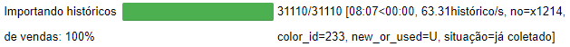

- Carga de `dct_guia_precos` a partir de arquivo pickle, ao invés da coleta online.

```python
# depois da importação inicial (demorada), dicionário foi salvo em arquivo pickle
# e pode ser carregado desse arquivo a qualquer tempo sem necessidade de nova coleta.
dct_guia_precos = pickle2object(tcc.pckl_dct_guia_precos)
```

```
Lido: d:\jup_ws\tcc\bricklink\dct_guia_precos.pickle
Tamanho: 73119862 bytes
Modifificado em: 30/07/2021 20:12:57
```

- Dataframe `df_guia_precos` com histórico de vendas das peças de interesse.
- Troca:
  - de `seq`: número de sequencial de um item de pedido dentro do grupo `(no, color_id, new_or_used)`
  - por `ord_itm_id`: número de sequencial de todos itens de pedidos reordenados por `date_ordered` (mantendo ordem da coleta original dentro da mesma `date_ordered`).

```python
df_guia_precos = (
    pd.concat(dct_guia_precos, names=['no','color_id','new_or_used', 'seq'])
    .sort_values(by='date_ordered')
    .pipe(lambda df: df
        .assign(ord_itm_id=np.arange(df.shape[0]))
        .reset_index(level='seq', drop=True)
        .set_index('ord_itm_id', append=True)
    )
)
```

- Amostra e dimensões do dataframe.

```python
d_pd(df_guia_precos, head=3, sample=3, tail=3)
```

| no | color_id | new_or_used | ord_itm_id | quantity | unit_price | seller_country_code | buyer_country_code | date_ordered |
| --- | --- | --- | --- | --- | --- | --- | --- | --- |
| 3005 | 80 | U | 0 | 10 | 0.0250 | PL | PL | 2016-12-13T18:42:52.050Z |
| 3010 | 11 | U | 1 | 2 | 0.0550 | SE | CA | 2016-12-14T18:03:46.683Z |
| 3065 | 12 | U | 2 | 1 | 0.0700 | SE | CA | 2016-12-14T18:03:46.683Z |
| 3003 | 156 | N | 800205 | 1 | 0.0700 | US | US | 2021-05-04T08:21:18.383Z |
| 3001 | 2 | U | 992748 | 4 | 0.1200 | UK | UK | 2021-06-01T13:26:22.820Z |
| 3005 | 150 | N | 1134553 | 3 | 0.0910 | AU | AU | 2021-06-26T01:28:31.253Z |
| 3622 | 85 | U | 1332486 | 200 | 0.0690 | CZ | IE | 2021-07-29T00:36:49.513Z |
| 6111 | 86 | U | 1332487 | 2 | 0.7500 | US | US | 2021-07-29T00:41:34.067Z |
| 30145 | 11 | N | 1332488 | 1 | 0.4051 | AU | AU | 2021-07-29T01:37:47.683Z |

```
(1332489, 5)
```

- Resumo técnico.

```python
df_guia_precos.info()
```

```
<class 'pandas.core.frame.DataFrame'>
MultiIndex: 1332489 entries, ('3005', 80, 'U', 0) to ('30145', 11, 'N', 1332488)
Data columns (total 5 columns):
 #   Column               Non-Null Count    Dtype
---  ------               --------------    -----
 0   quantity             1332489 non-null  int64
 1   unit_price           1332489 non-null  object
 2   seller_country_code  1332489 non-null  object
 3   buyer_country_code   1332489 non-null  object
 4   date_ordered         1332489 non-null  object
dtypes: int64(1), object(4)
memory usage: 102.1+ MB
```

- Salvamento e teste da carga do dataframe em formato pickle.

```python
frame2pickle(frame=df_guia_precos, p_pickle=tcc.pckl_df_guia_precos)
```

```
Salvo: d:\jup_ws\tcc\bricklink\df_guia_precos.pickle
Tamanho: 91964293 bytes
Modifificado em: 27/10/2021 13:31:45
```

```python
_ = pickle2frame(p_pickle=tcc.pckl_df_guia_precos)
del _
```

```
Lido: d:\jup_ws\tcc\bricklink\df_guia_precos.pickle
Tamanho: 91964293 bytes
Modifificado em: 27/10/2021 13:31:45
```